# Tools for Scientific Writing

#### WANGLAB Research Training Series

Dr. Yong Wang

WANGLAB @ PHYS @ UARK

Version 2022.12

## Two Types of Writing Tools

- WYSIWYG
  - Microsoft Word
  - Google Docs
  - ……
- Non-WYSIWYG
  - LaTeX (and variants)
  - Markdown (and variants)
  - Typst

## Pros of WYSIWYG Tools

- You see the “almost-final” product as you write
- “Standard” format for submitting manuscripts in many fields
  - Exceptions: Math, Physics, CS
- Easy to learn/use – no special skills required
- Fast in many cases
- Collaborative editing

## Cons of WYSIWYG Tools

- It is hard to write equations (if there are a lot)
- The current “standard” is “LaTeX” for journals in Math and Physics
- It may be slow when the document is big (e.g., with a lot of high-quality figures)
- Compatibility/consistency may be an issue (e.g., format may change from platform to platform)
- Difficult to number and refer to figures and tables

## Pros of LaTeX

- Standard for journals in Math and Physics
  - If you are a physics Ph.D. student, you should learn the basics of LaTeX.
- Great for dealing with equations and math notations
- Separation of content and style
- Auto-numbering and referring to figures and tables
- Plain text and thus consistent from platform to platform

## Cons of LaTeX

- Typically do not see what you get when you write
- Fairly steep learning curve
- Collaborators unfamiliar with LaTeX will have difficulty reviewing your manuscripts
- Difficult to master high-level functions

## Combination: Markdown + Pandoc

- **Markdown**: a simplified version of LaTeX
- **Pandoc**: a universal document converter

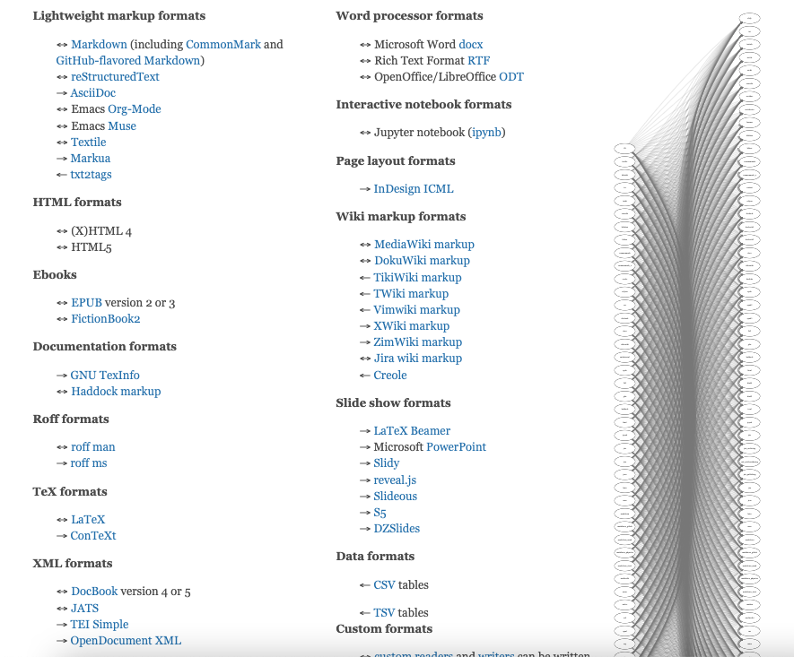

## Quarto - a tool-chain for Markdown+Pandoc

[figure not shown]

## Additional features/advantages of Quarto

- Easy to include and run Python code (and other code)
- Easy to convert among different formats
  - high-quality articles, reports, presentations, websites, blogs, and books in HTML, PDF, MS Word, ePub, and more.

## Workflow 1 for Writing in WANGLAB

- If your manuscript will have more than 10 symbols and equations
  1. Write your manuscript in Markdown (Quarto)
     - VS Code + Quarto Extension
     - RStudio
  2. Export as PDF for reviewing and submission
     - Export to LaTeX for tweaking if needed
     - Export to Word for collaborators’ reviewing if needed

## Workflow 2 for Writing in WANGLAB

- If you don’t know LaTeX (and do not want to learn LaTeX);
- **AND** if your manuscript will have less than 10 symbols and equations

  Simply use **Google Docs** for writing and for submission!

Note: Microsoft Word may behave differently on different OS (Windows *vs* MacOS *vs* Linux (the PI uses Linux))

## Preferred Workflow in WangLab: Markdown (Quarto)

- Cross-platform (Windows, Mac, Linux, iPad)
- Plain-text (consistency between different versions)
- Can easily convert to any format
- **Reproductive research** (easy to include and run code)
- Easy to label and reference figures
- Easy to include equations and math